# Salmon Estimation Analysis

```r
library(DESeq2)
library(GenomicFeatures)
library(tximport)
```

So we’ve got our transcript abundance estimations, but we need to convert them to counts for `DESeq2` to work with them. In order to do that, we’re using `tximport`. First we need to construct a table that maps transcript names to gene names since we’re interested in gene-level differential expression analysis. We’ll use the GFF file for our genome to make one.

```r
txdb <- makeTxDbFromGFF("../data/raw/GCF_000146045.2_R64_genomic.gff")
k <- keys(txdb, keytype="TXNAME")
tx2gene <- select(txdb, k, "GENEID", "TXNAME")
```

Once that’s done we can read in our estimations and use `tximport` to convert everything properly.

```r
samples <- c("SRR1066657", "SRR1066658", "SRR1066659", "SRR1066660")
files <- file.path("..", "data", "processed", samples, "quant.sf")
names(files) <- paste0(samples)
txi <- tximport(files, type="salmon", tx2gene=tx2gene)
```

Then we need to set some metadata and throw it all into `DESeq2` and run the pipeline.

```r
coldata <- data.frame(row.names=c("WT_NR_A", "WT_NR_B", "WT_CR_A", "WT_CR_B"), "condition"=c("Control", "Control", "Treat", "Treat"))
dds <- DESeqDataSetFromTximport(txi, coldata, ~condition)
dds <- DESeq(dds)
```

Let’s start with looking at what are the top $50$ most differentially expressed genes by p-value.

```r
res <- results(dds)
as.data.frame(res[order(res$pvalue),][0:50, ])
```

|  | baseMean | log2FoldChange | lfcSE | stat | pvalue | padj |
| --- | --- | --- | --- | --- | --- | --- |
| ADH2 | 67171.811 | 8.246038 | 0.2697545 | 30.56868 | 3.193181e-205 | 1.915270e-201 |
| JEN1 | 84013.428 | 7.408637 | 0.2889985 | 25.63556 | 6.126206e-145 | 1.837249e-141 |
| ADY2 | 59650.213 | 8.176171 | 0.3262661 | 25.05982 | 1.364430e-138 | 2.727951e-135 |
| ACS1 | 20777.860 | 5.976367 | 0.2452757 | 24.36592 | 3.931630e-131 | 5.895479e-128 |
| ARO9 | 12361.140 | 7.058001 | 0.2956395 | 23.87368 | 5.749998e-126 | 6.897697e-123 |
| RGI2 | 9574.937 | 6.719737 | 0.2904451 | 23.13600 | 2.011339e-118 | 2.010668e-115 |
| CIT3 | 19059.362 | 6.792590 | 0.2994078 | 22.68675 | 6.054671e-114 | 5.187988e-111 |
| FBP1 | 9803.761 | 5.985421 | 0.2675218 | 22.37358 | 7.119146e-111 | 5.337580e-108 |
| ZPS1 | 20770.300 | -5.669671 | 0.2536271 | -22.35435 | 1.095302e-110 | 7.299578e-108 |
| YGR067C | 6998.288 | 6.060614 | 0.2839885 | 21.34106 | 4.721519e-101 | 2.831967e-98 |

[output cut: 40 more lines]

Ok, let’s see log fold change where genes with a $p < 0.05$ are in red.

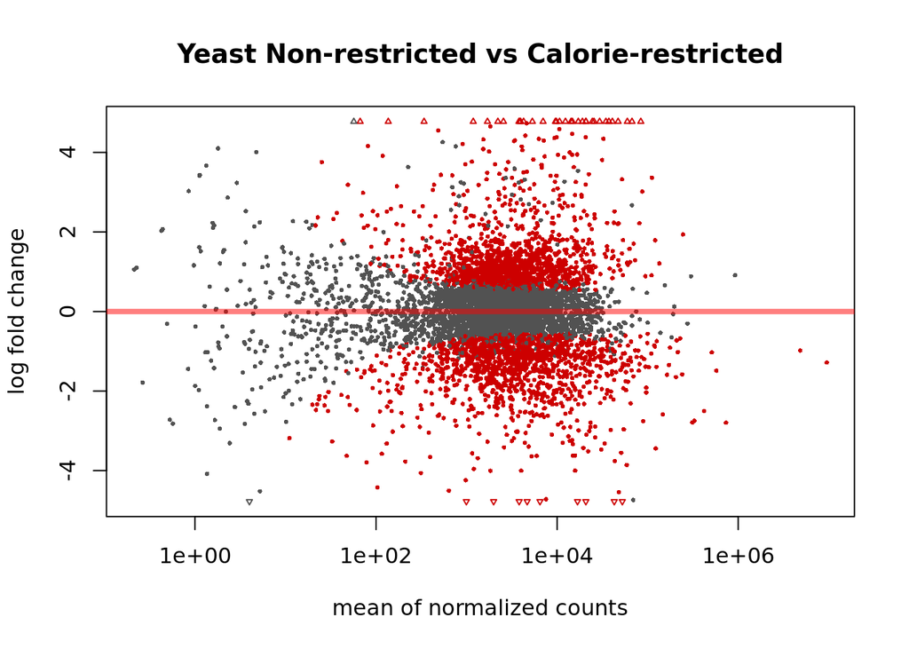

```r
plotMA(res, 0.05, main="Yeast Non-restricted vs Calorie-restricted")
```

Wow! That’s a lot of highly-differentially expressed genes!

Let’s see how different they look between the two groups with a PCA plot.

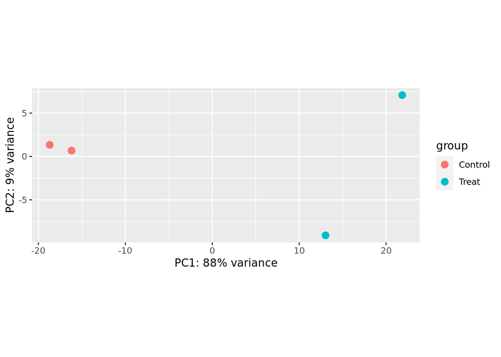

```r
plotPCA(rlogTransformation(dds, blind=TRUE))
```

Looks like the two groups definitely have a different expression profile!